# CoSIBS Project: LLM Model Comparison for Agentic AI Benchmarking

Zengtao Xing

July 26, 2026

# 1 Introduction

This report summarizes results the agentic AI benchmarking pipeline where the underlying LLM was varied while all other pipeline parameters were held constant. The LLM is responsible for retrieving and configuring candidate predictive models for a hyperlipidemia classification task, which are then evaluated for performance.

**Area under the receiver operating characteristic curve (AUROC)** is used as the primary performance metric rather than raw accuracy, because AUROC accounts for both the true-positive and false-positive rate and is more robust to the small number of hyperlipidemia diagnoses.

# 2 Methods

## 2.1 Experimental Design

A one-factor-at-a-time design was used, varying only the LLM across four levels: **GPT-5.2**, **GPT-5.4**, **GPT-5.4-mini**, and **GPT-5.6-sol**. All other pipeline parameters (temperature, prompt template, and number of candidate models retrieved) were held fixed across runs. At least ten independent runs were collected per LLM.

## 2.2 Statistical Analysis Plan

Within each run, the LLM retrieves and fits three candidate models (e.g., logistic regression, random forest, XGBoost). Because these models are benchamrked together, they are not independent observations. To have independence, metrics were averaged **within each run** to satisfy the independence assumption of one-way ANOVA.

The following statistical tests were used to find differences in LLM means/effects:

1. One-way ANOVA
2. Welch’s ANOVA
3. Kruskal-Wallis test
4. Games-Howell pairwise differences

# 3 Packages

```r
# install.packages(c("dplyr", "car", "ggplot2", "rstatix", "knitr"))
library(dplyr)
library(car)
library(rstatix)
library(ggplot2)
library(knitr)
library(stringr)
library(kableExtra)
```

# 4 Data Compilation

## 4.1 Building the Run-Level Dataframe

The raw JSON results from each run were compiled into a single long-format dataframe (with the help of Claude), with one row per run × algorithm combination. Missing metrics (e.g., runs where XGBoost failed to execute) are encoded as `NA_real_`.

```r
df <- tribble(
  ~group, ~run, ~algorithm, ~accuracy, ~auroc, ~brier, ~f1, ~precision, ~recall, ~threshold,

  # ---------------- gpt-5.2 (11 runs) ----------------
  "gpt-5.2", 1, "logistic_regression", 0.34552845528455284, 0.5355780022446689, 0.36821516241928626, 0.4755700325732899, 0.3230088495575221, 0.9012345679012346, 1.83541123016041e-09,
  "gpt-5.2", 1, "random_forest",       0.4146341463414634,  0.5789375233819678, 0.217147662601626,   0.4782608695652174, 0.3384615384615385, 0.8148148148148148, 0.28,
  "gpt-5.2", 1, "xgboost",             0.4146341463414634,  0.6134680134680135, 0.24187880674759857, 0.5,                0.34782608695652173,0.8888888888888888, 0.0330415703356266,

  "gpt-5.2", 2, "lightgbm",       0.32926829268292684, 0.5, 0.22085258062076668, 0.4954128440366972, 0.32926829268292684, 1.0, 0.32789115646258504,
  "gpt-5.2", 2, "random_forest",  0.32926829268292684, 0.5, 0.22085309905425582, 0.4954128440366972, 0.32926829268292684, 1.0, 0.3277142857142856,
  "gpt-5.2", 2, "xgboost",        0.32926829268292684, 0.5, 0.22085258058078594, 0.4954128440366972, 0.32926829268292684, 1.0, 0.32789117097854614,

  "gpt-5.2", 3, "logistic_regression",              0.32926829268292684, 0.5, 0.22085258497426277, 0.4954128440366972, 0.32926829268292684, 1.0, 0.3278895767348184,
  "gpt-5.2", 3, "random_forest_classifier",         0.32926829268292684, 0.5, 0.22085093453156943, 0.4954128440366972, 0.32926829268292684, 1.0, 0.32976870748299314,
  "gpt-5.2", 3, "xgboost_extreme_gradient_boosting",0.32926829268292684, 0.5, 0.2208659009171721,  0.4954128440366972, 0.32926829268292684, 1.0, 0.32536742091178894,

  "gpt-5.2", 4, "logistic_regression", 0.33739837398373984, 0.45536849981294425, 0.32117345417474885, 0.48253968253968255, 0.3247863247863248, 0.9382716049382716, 0.0003545654918688194,
  "gpt-5.2", 4, "random_forest",       0.33739837398373984, 0.5012345679012346,  0.23162142873931058, 0.4953560371517028, 0.3305785123966942, 0.9876543209876543, 0.12,
  "gpt-5.2", 4, "xgboost",             0.42276422764227645, 0.49614665170220723, 0.2815598044474337,  0.4365079365079365, 0.3216374269005848, 0.6790123456790124, 0.08168642967939377,

  "gpt-5.2", 5, "gradient_boosting_machines_gbm", 0.3983739837398374,  0.5780396558174336, 0.21918745310570673, 0.5066666666666667,  0.3470319634703196, 0.9382716049382716, 0.16076323382918842,
  "gpt-5.2", 5, "random_forest",                  0.3333333333333333,  0.5552936775158998, 0.2467989268292683,  0.49693251533742333, 0.3306122448979592, 1.0,                0.002,
  "gpt-5.2", 5, "support_vector_machines_svm",    0.3333333333333333,  0.421623643845866,  0.220891956168234,   0.47435897435897434, 0.3203463203463203, 0.9135802469135802, 0.32809249986954586,

  "gpt-5.2", 6, "logistic_regression",              0.32926829268292684, 0.5, 0.22085085928269002, 0.4954128440366973, 0.32926829268292684, 1.0, 0.32884976419786244,
  "gpt-5.2", 6, "random_forest",                    0.32926829268292684, 0.5, 0.22085292471876558, 0.4954128440366973, 0.32926829268292684, 1.0, 0.32777142857142844,
  "gpt-5.2", 6, "xgboost_extreme_gradient_boosting",0.32926829268292684, 0.5, 0.2208659009171721,  0.4954128440366973, 0.32926829268292684, 1.0, 0.32536742091178894,

  "gpt-5.2", 7, "lightgbm",      0.34146341463414637, 0.535465768799102,  0.23900812525134155, 0.49375,             0.3305439330543933, 0.9753086419753086, 0.03437740890524628,
  "gpt-5.2", 7, "random_forest", 0.3333333333333333,  0.5331088664421998, 0.2717037733926648,  0.47770700636942676, 0.3218884120171674, 0.9259259259259259, 0.007630683217167498,
  "gpt-5.2", 7, "xgboost",       0.34146341463414637, 0.5307519640852975, 0.24667952690105371, 0.4873417721518987,  0.3276595744680851, 0.9506172839506173, 0.03524316847324371,

  "gpt-5.2", 8, "logistic_regression", 0.4024390243902439, 0.4919191919191919, 0.22996542312446155, 0.43243243243243246, 0.3146067415730337, 0.691358024691358,   0.32793834325133847,
  "gpt-5.2", 8, "random_forest",       0.5,                0.4853722409277964, 0.2643795822742859,  0.3626943005181347,  0.3125,             0.43209876543209874, 0.32433177550566156,
  "gpt-5.2", 8, "xgboost",             NA_real_,           NA_real_,           NA_real_,             NA_real_,            NA_real_,           NA_real_,            NA_real_,

  "gpt-5.2", 9, "logistic_regression", 0.32926829268292684, 0.5, 0.22085258497426277, 0.4954128440366973, 0.32926829268292684, 1.0, 0.3278895767348184,
  "gpt-5.2", 9, "random_forest",       0.32926829268292684, 0.5, 0.22085708027958334, 0.4954128440366973, 0.32926829268292684, 1.0, 0.3267392290249434,
  "gpt-5.2", 9, "xgboost",             NA_real_,            NA_real_, NA_real_,            NA_real_,            NA_real_,            NA_real_, NA_real_,

  "gpt-5.2", 10, "logistic_regression", 0.33739837398373984, 0.5236812570145903, 0.39786863063220207, 0.4792332268370607,  0.3232758620689655,  0.9259259259259259, 3.1432218136504514e-10,
  "gpt-5.2", 10, "random_forest",       0.4268292682926829,  0.6154133931911709, 0.21306691656064658, 0.5017667844522968,  0.35148514851485146, 0.8765432098765432, 0.2927942718273594,
  "gpt-5.2", 10, "xgboost",             0.33739837398373984, 0.5236812570145903, 0.39786863063220207, 0.4792332268370607,  0.3232758620689655,  0.9259259259259259, 3.1432218136504514e-10,

  "gpt-5.2", 11, "logistic_regression", 0.3333333333333333,  0.559670781893004,  0.2253631159775527,  0.49382716049382713, 0.3292181069958848,  0.9876543209876543, 0.0143180644288395,
  "gpt-5.2", 11, "random_forest",       0.32926829268292684, 0.4832772166105499, 0.2418378739749688,  0.4891640866873065,  0.32644628099173556, 0.9753086419753086, 0.018126118326118323,

  # ---------------- gpt-5.4 (10 runs) ----------------
  "gpt-5.4", 1, "logistic_regression",       0.573170731707317,   0.5737373737373737, 0.2214851401798883,  0.378698224852071,  0.36363636363636365, 0.3950617283950617, 0.338357061612245,
  "gpt-5.4", 1, "random_forest_classifier",  0.6544715447154471,  0.6118967452300785, 0.21413978760789093, 0.33070866141732286,0.45652173913043476, 0.25925925925925924,0.37796831443919376,
  "gpt-5.4", 1, "support_vector_machine_svm",0.6016260162601627,  0.5509913954358399, 0.21958582247046737, 0.3,                0.3559322033898305,  0.25925925925925924,0.33046439975722747,
```

```r
  "gpt-5.4", 2, "logistic_regression",       0.35365853658536583, 0.5378226711560045, 0.3722690696099948,  0.4752475247524752, 0.32432432432432434, 0.8888888888888888, 1.2296560393423142e-07,
  "gpt-5.4", 2, "random_forest_classifier",  0.34146341463414637, 0.5832023943135054, 0.21767134146341463, 0.5,                0.3333333333333333,  1.0,                0.16,
  "gpt-5.4", 2, "support_vector_machine_svm",0.45528455284552843, 0.5013842124953236, 0.2208005078052702,  0.45081967213114754,0.3374233128834356,  0.6790123456790124, 0.3225869330277011,

  "gpt-5.4", 3, "logistic_regression", 0.33739837398373984, 0.5439955106621773, 0.3732893736176403,  0.4792332268370607, 0.3232758620689655, 0.9259259259259259, 5.366680802513263e-10,
  "gpt-5.4", 3, "random_forest",       0.3943089430894309,  0.5989898989898991, 0.2146861788617886,  0.4879725085910653, 0.3380952380952381, 0.8765432098765432, 0.25,

  "gpt-5.4", 4, "logistic_regression", 0.3333333333333333,  0.514702581369248,  0.3788509426484114,  0.4875,               0.3263598326359833, 0.9629629629629629, 1.269859791000437e-07,
  "gpt-5.4", 4, "random_forest",       0.4065040650406504,  0.611821922933034,  0.21248026196928638, 0.5067567567567568,   0.3488372093023256, 0.9259259259259259, 0.24,
  "gpt-5.4", 4, "xgboost",             NA_real_,            NA_real_,           NA_real_,            NA_real_,             NA_real_,           NA_real_,           NA_real_,

  "gpt-5.4", 5, "logistic_regression",                       0.3902439024390244,  0.5357276468387578, 0.22053332736607434, 0.506578947368421,   0.3452914798206278,  0.9506172839506173, 0.3156685435290104,
  "gpt-5.4", 5, "random_forest_classifier",                  0.3333333333333333,  0.5675645342312009, 0.21968364689134648, 0.49382716049382713, 0.3292181069958848,  0.9876543209876543, 0.304241801238824,
  "gpt-5.4", 5, "support_vector_machine_svm_with_rbf_kernel",0.32926829268292684, 0.4264870931537598, 0.22087622659977688, 0.4891640866873065,  0.32644628099173556, 0.9753086419753086, 0.3261981992225341,

  "gpt-5.4", 6, "logistic_regression",              0.34552845528455284, 0.4804339693228582, 0.29830434594819943, 0.4888888888888889,  0.32905982905982906, 0.9506172839506173, 0.00427476128215051,
  "gpt-5.4", 6, "random_forest",                    0.4065040650406504,  0.6183314627759072, 0.21249932249322492, 0.5034013605442177,  0.3474178403755869,  0.9135802469135802, 0.25,
  "gpt-5.4", 6, "xgboost_extreme_gradient_boosting", NA_real_,           NA_real_,            NA_real_,            NA_real_,            NA_real_,            NA_real_,           NA_real_,

  "gpt-5.4", 7, "logistic_regression", 0.32926829268292684, 0.5282454171343061, 0.3696306939856307,  0.48598130841121495, 0.325,               0.9629629629629629, 1.263803073190228e-11,
  "gpt-5.4", 7, "random_forest",       0.44308943089430897, 0.5954732510288065, 0.21541554878048783, 0.4981684981684982,  0.3541666666666667,  0.8395061728395061, 0.27,
  "gpt-5.4", 7, "xgboost",             NA_real_,            NA_real_,           NA_real_,            NA_real_,            NA_real_,            NA_real_,           NA_real_,

  "gpt-5.4", 8, "random_forest", 0.4024390243902439, 0.629105873550318, 0.219960298102981, 0.49829351535836175, 0.3443396226415094, 0.9012345679012346, 0.3333333333333333,

  "gpt-5.4", 9, "gradient_boosting_machine_gbm", 0.42276422764227645, 0.6133931911709689, 0.22362765881556687, 0.5202702702702703, 0.3581395348837209,  0.9506172839506173, 0.14140628878976916,
  "gpt-5.4", 9, "random_forest",                 0.32926829268292684, 0.5634118967452302, 0.22985075475525646, 0.4954128440366973, 0.32926829268292684, 1.0,                0.2830188679245283,
  "gpt-5.4", 9, "support_vector_machine_svm",    0.32926829268292684, 0.4427609427609427, 0.2341625309011664,  0.4954128440366973, 0.32926829268292684, 1.0,                0.26168224299065423,

  "gpt-5.4", 10, "logistic_regression", 0.32926829268292684, 0.5401795735129068, 0.22068278694994947, 0.4954128440366973, 0.32926829268292684, 1.0,                0.0,
  "gpt-5.4", 10, "random_forest",       0.32926829268292684, 0.5057987280209502, 0.2207713031685464,  0.4827586206896552, 0.3235294117647059,  0.9506172839506173, 0.31903847483737335,
  "gpt-5.4", 10, "xgboost",             NA_real_,            NA_real_,           NA_real_,            NA_real_,            NA_real_,            NA_real_,           NA_real_,

  # ---------------- gpt-5.4-mini (12 runs) ----------------
  "gpt-5.4-mini", 1, "logistic_regression",              0.3821138211382114, 0.5274971941638609, 0.38986949818620353, 0.4864864864864865, 0.33488372093023255, 0.8888888888888888, 1.424986430444194e-07,
  "gpt-5.4-mini", 1, "random_forest",                    0.3617886178861789, 0.5929292929292929, 0.21504075203252032, 0.4852459016393443, 0.33035714285714285, 0.9135802469135802, 0.23,
  "gpt-5.4-mini", 1, "xgboost_extreme_gradient_boosting", 0.3699186991869919, 0.6024691358024691, 0.24045158922672272, 0.5016077170418006, 0.3391304347826087, 0.9629629629629629, 0.022018438205122948,

  "gpt-5.4-mini", 2, "logistic_regression",      1.0,                 1.0, 4.7003810652642314e-05, 1.0,               1.0, 1.0,                0.966575527074772,
  "gpt-5.4-mini", 2, "random_forest_classifier", 0.967479674796748,   1.0, 0.010997865853658535,    0.948051948051948,1.0, 0.9012345679012346, 0.79,
  "gpt-5.4-mini", 2, "xgboost",                  1.0,                 1.0, 7.820214705134276e-06,   1.0,               1.0, 1.0,                0.9960005879402161,

  "gpt-5.4-mini", 3, "random_forest_classifier",         0.3617886178861789, 0.582865693976805, 0.2166183830171635,  0.47840531561461797, 0.32727272727272727, 0.8888888888888888, 0.23,
  "gpt-5.4-mini", 3, "support_vector_machine_svm",       0.3333333333333333, 0.5170594837261504, 0.220709922689941,  0.4906832298136646,  0.3278008298755187,  0.9753086419753086, 0.31669521856777666,
  "gpt-5.4-mini", 3, "xgboost_extreme_gradient_boosting", 0.524390243902439,  0.621623643845866, 0.23767435550689697, 0.5224489795918368,  0.3902439024390244,  0.7901234567901234, 0.10514029860496521,
```

```r
  "gpt-5.4-mini", 4, "logistic_regression",       0.3821138211382114, 0.5323606434717546, 0.35839209098213287, 0.4864864864864865,  0.33488372093023255, 0.8888888888888888, 9.408835347140976e-07,
  "gpt-5.4-mini", 4, "random_forest_classifier",  0.33739837398373984,0.6319117096894875, 0.21068028455284551, 0.48580441640378547, 0.326271186440678,   0.9506172839506173, 0.185,
  "gpt-5.4-mini", 4, "support_vector_machine_svc",0.3333333333333333, 0.4963711185933408, 0.22108348725898697, 0.49693251533742333, 0.3306122448979592,  1.0,                0.3124379867944233,

  "gpt-5.4-mini", 5, "logistic_regression",      0.3333333333333333,  0.518742985409652,  0.23429039056100148, 0.47770700636942676, 0.3218884120171674, 0.9259259259259259, 0.15227189667355107,
  "gpt-5.4-mini", 5, "random_forest_classifier", 0.32926829268292684, 0.6430976430976432, 0.21121187895212282, 0.4954128440366973,  0.32926829268292684,1.0,                0.0,
  "gpt-5.4-mini", 5, "xgboost",                  0.3902439024390244,  0.6159371492704826, 0.25114116072654724, 0.5098039215686274,  0.3466666666666667, 0.9629629629629629, 0.018346205353736877,

  "gpt-5.4-mini", 6, "logistic_regression", 1.0, 1.0, 0.00033987544786001975, 1.0, 1.0, 1.0, 0.9885811608520114,
  "gpt-5.4-mini", 6, "random_forest",       1.0, 1.0, 0.022320189701897017,   1.0, 1.0, 1.0, 0.6233333333333333,
  "gpt-5.4-mini", 6, "xgboost",             1.0, 1.0, 1.4807117905177016e-05, 1.0, 1.0, 1.0, 0.9920083284378052,

  "gpt-5.4-mini", 7, "logistic_regression",     0.328, 0.47590011614401856, 0.26848607018475795, 0.4939759036144578, 0.328, 1.0,                2.4488805072302775e-05,
  "gpt-5.4-mini", 7, "random_forest_classifier",0.32,  0.5215229384436701,  0.22699364554358703,  0.4817073170731707, 0.32113821138211385,0.9634146341463414, 0.155,
  "gpt-5.4-mini", 7, "support_vector_machine_svm",0.328,0.49085365853658536,0.2206616954121636,   0.4939759036144578, 0.328, 1.0,                0.0,

  "gpt-5.4-mini", 8, "lightgbm",             0.3617886178861789,  0.5468013468013467, 0.27767913734004696, 0.49517684887459806, 0.3347826086956522,  0.9506172839506173, 0.006651109552742605,
  "gpt-5.4-mini", 8, "logistic_regression",  0.34959349593495936, 0.4719790497568275, 0.3974243583558975,  0.4936708860759494,  0.33191489361702126, 0.9629629629629629, 3.95141905266612e-10,
  "gpt-5.4-mini", 8, "random_forest",        0.32926829268292684, 0.5901608679386456, 0.21764308943089428, 0.4954128440366973,  0.32926829268292684, 1.0,                0.15666666666666668,

  "gpt-5.4-mini", 9, "lightgbm_light_gradient_boosting_machine", 0.3902439024390244,  0.5967078189300411, 0.2723242294004079,  0.5033112582781457,  0.3438914027149321, 0.9382716049382716, 0.003819564009478319,
  "gpt-5.4-mini", 9, "random_forest",                            0.3983739837398374,  0.5881032547699213, 0.21570727190605238, 0.5,                 0.34418604651162793,0.9135802469135802, 0.25333333333333335,
  "gpt-5.4-mini", 9, "xgboost_extreme_gradient_boosting",        0.4186991869918699,  0.6104002992891883, 0.23111432790756226, 0.49110320284697506, 0.345,              0.8518518518518519, 0.0876733735203743,

  "gpt-5.4-mini", 10, "gradient_boosting_classifier",  0.46747967479674796, 0.5842873176206509, 0.22229298417534318, 0.45643153526970953, 0.34375,             0.6790123456790124, 0.21828088505299315,
  "gpt-5.4-mini", 10, "random_forest_classifier",      0.4065040650406504,  0.5829405162738496, 0.21403333333333335, 0.4930555555555556,  0.34299516908212563,0.8765432098765432, 0.25,
  "gpt-5.4-mini", 10, "support_vector_machine_svm",    0.34552845528455284, 0.49270482603815935,0.22109188797652304, 0.47896440129449835, 0.32456140350877194,0.9135802469135802, 0.31923949276373764,

  "gpt-5.4-mini", 11, "logistic_regression", 0.6707317073170732, 0.39169472502805835, 0.3043714353536765,  0.0,                  0.0,                0.0,                  1.0,
  "gpt-5.4-mini", 11, "random_forest",       0.6747967479674797, 0.4132809577254022,  0.2588581197689133,  0.024390243902439025, 1.0,                0.012345679012345678, 0.8793333333333332,
  "gpt-5.4-mini", 11, "xgboost",             0.6585365853658537, 0.5349046015712682,  0.2310888022184372,  0.045454545454545456, 0.2857142857142857, 0.024691358024691357, 0.5407688021659851,

  "gpt-5.4-mini", 12, "lightgbm",            0.32926829268292684, 0.5,                0.22094107130159188, 0.4954128440366973, 0.32926829268292684, 1.0, 0.0,
  "gpt-5.4-mini", 12, "logistic_regression", 0.34146341463414637, 0.509090909090909, 0.22089868121324369, 0.5,                0.3333333333333333,  1.0, 0.3378637861773547,
  "gpt-5.4-mini", 12, "xgboost",             0.32926829268292684, 0.5,                0.2209661900997162,  0.4954128440366973, 0.32926829268292684, 1.0, 0.0,

  # ---------------- gpt-5.6-sol (14 runs) ----------------
  "gpt-5.6-sol", 1, "gradient_boosting_classifier",  0.36585365853658536, 0.6128694350916574, 0.22525513057194058, 0.5031847133757962, 0.33905579399141633, 0.9753086419753086, 0.10037818229745232,
  "gpt-5.6-sol", 1, "random_forest_classifier",      0.4186991869918699,  0.6025065469509914, 0.2197634247685411,  0.5051903114186851, 0.35096153846153844, 0.9012345679012346, 0.31861207184612944,
  "gpt-5.6-sol", 1, "support_vector_machine_svm",    0.34959349593495936, 0.5448559670781894, 0.2208542679200526,  0.5031055900621118, 0.3360995850622407,  1.0,                0.32637586057303336,

  "gpt-5.6-sol", 2, "random_forest",             0.4349593495934959,  0.6004489337822672, 0.21811419049987366, 0.508833922261484,   0.3564356435643564, 0.8888888888888888, 0.3063960695993427,
  "gpt-5.6-sol", 2, "support_vector_machines_svm",0.3333333333333333,  0.4298540965207632, 0.2208872868366391,  0.49693251533742333, 0.3306122448979592,  1.0,                0.32548737989039495,
  "gpt-5.6-sol", 2, "xgboost",                    0.3333333333333333,  0.6039655817433596, 0.2158094201672745,  0.49693251533742333, 0.3306122448979592,  1.0,                0.24208248253823123,
```

```r
  "gpt-5.6-sol", 3, "lightgbm",                  0.34959349593495936, 0.5881780770669659, 0.2177907638698843,  0.5,                 0.33472803347280333, 0.9876543209876543, 0.28559501825195294,
  "gpt-5.6-sol", 3, "random_forest_classifier",  0.5040650406504065,  0.5877291432846988, 0.21725778600166692, 0.47413793103448276, 0.36423841059602646, 0.6790123456790124, 0.3157288833760119,
  "gpt-5.6-sol", 3, "xgboost",                   0.3821138211382114,  0.588327721661055,  0.21598365928530833, 0.5,                 0.34080717488789236, 0.9382716049382716, 0.2568023750788275,

  "gpt-5.6-sol", 4, "lightgbm",      0.4146341463414634,  0.5976056864945753, 0.2157117532980871,  0.5102040816326531,  0.352112676056338,   0.9259259259259259, 0.29646886221710395,
  "gpt-5.6-sol", 4, "random_forest", 0.43089430894308944, 0.5932285821174709, 0.21969385883132875, 0.48905109489051096, 0.3471502590673575,  0.8271604938271605, 0.3194669320300703,
  "gpt-5.6-sol", 4, "xgboost",       0.3780487804878049,  0.607482229704452,  0.2175384029795331,  0.5080385852090032,  0.34347826086956523, 0.9753086419753086, 0.30635464984681693,

  "gpt-5.6-sol", 5, "logistic_regression",       0.32926829268292684, 0.5802469135802469, 0.21804532752403682, 0.4954128440366973, 0.32926829268292684, 1.0,                0.2762326199869898,
  "gpt-5.6-sol", 5, "random_forest_classifier",  0.32926829268292684, 0.5859708193041525, 0.21902640551000935, 0.4891640866873065, 0.32644628099173556, 0.9753086419753086, 0.2856239506779278,
  "gpt-5.6-sol", 5, "xgboost",                   0.45934959349593496, 0.6042648709315376, 0.21378032405784134, 0.5055762081784386, 0.3617021276595745,  0.8395061728395061, 0.28380755817037995,

  "gpt-5.6-sol", 6, "logistic_regression",              0.32926829268292684, 0.5500187055742611, 0.21866090881257597, 0.49230769230769234, 0.32786885245901637, 0.9876543209876543, 0.3033822086805061,
  "gpt-5.6-sol", 6, "random_forest",                    0.3902439024390244,  0.5951365506921062, 0.21964855273950887, 0.49324324324324326, 0.3395348837209302,  0.9012345679012346, 0.3167681451027182,
  "gpt-5.6-sol", 6, "xgboost_extreme_gradient_boosting", 0.44715447154471544, 0.638757949869061,  0.23377574262917178, 0.5142857142857142,  0.36180904522613067, 0.8888888888888888, 0.06463021039962769,

  "gpt-5.6-sol", 7, "random_forest",              0.3333333333333333,  0.5814814814814815, 0.21833813190906373, 0.49693251533742333, 0.3306122448979592,  1.0,                0.2706751285437187,
  "gpt-5.6-sol", 7, "support_vector_machines_svm",0.34146341463414637, 0.542536475869809,  0.22077543910979924, 0.5,                 0.3333333333333333,  1.0,                0.32386220501629037,
  "gpt-5.6-sol", 7, "xgboost",                    0.43902439024390244, 0.5950617283950618, 0.21528082497087467, 0.49635036496350365, 0.35233160621761656, 0.8395061728395061, 0.29463663758410064,

  "gpt-5.6-sol", 8, "gradient_boosting_classifier",  0.34552845528455284, 0.6182566404788626, 0.22348518070881737, 0.4984423676012461, 0.3333333333333333,  0.9876543209876543, 0.06015786755892765,
  "gpt-5.6-sol", 8, "random_forest_classifier",      0.4024390243902439,  0.562102506546951,  0.21896060779873247, 0.4693140794223827, 0.33163265306122447, 0.8024691358024691, 0.30381435843353516,
  "gpt-5.6-sol", 8, "support_vector_machine_svc",    0.3333333333333333,  0.4249158249158249, 0.22120587510778292, 0.4906832298136646, 0.3278008298755187,  0.9753086419753086, 0.32022127148107793,

  "gpt-5.6-sol", 9, "lightgbm",             0.3699186991869919,  0.5994014216236437, 0.21742766841196803, 0.5016077170418006,  0.3391304347826087,  0.9629629629629629, 0.28847862911830524,
  "gpt-5.6-sol", 9, "logistic_regression",  0.32926829268292684, 0.5354283576505798, 0.22105620644173568, 0.4954128440366973,  0.32926829268292684, 1.0,                0.25071557962646995,
  "gpt-5.6-sol", 9, "xgboost",              0.3333333333333333,  0.6004489337822672, 0.21653570225886148, 0.49693251533742333, 0.3306122448979592,  1.0,                0.24760659085861514,

  "gpt-5.6-sol", 10, "lightgbm",      0.3821138211382114,  0.5790497568275346, 0.2157447774774505,  0.5032679738562091,  0.3422222222222222,  0.9506172839506173, 0.2992059303670567,
  "gpt-5.6-sol", 10, "random_forest", 0.4268292682926829,  0.583426861204639,  0.21926015320495712, 0.49097472924187724, 0.3469387755102041,  0.8395061728395061, 0.3158919237572334,
  "gpt-5.6-sol", 10, "xgboost",       0.43089430894308944, 0.6065843621399177, 0.21646310377287453, 0.5035460992907801,  0.35323383084577115, 0.8765432098765432, 0.2980906116650275,

  "gpt-5.6-sol", 11, "logistic_regression", 0.4349593495934959,  0.5634493078937524, 0.2188427822263489,  0.505338078291815,   0.355,               0.8765432098765432, 0.3024836444784287,
  "gpt-5.6-sol", 11, "random_forest",       0.44715447154471544, 0.6014216236438459, 0.2165208658599439,  0.5,                 0.35602094240837695, 0.8395061728395061, 0.3011396575466156,
  "gpt-5.6-sol", 11, "xgboost",             0.34146341463414637, 0.6212495323606435, 0.25430671116041487, 0.4968944099378882,  0.33195020746887965, 0.9876543209876543, 0.002605562098324299,

  "gpt-5.6-sol", 12, "logistic_regression",     0.3333333333333333,  0.5473999251777029, 0.22011091089612547, 0.4875,              0.3263598326359833, 0.9629629629629629, 0.3055809985918014,
  "gpt-5.6-sol", 12, "random_forest_classifier",0.43089430894308944, 0.5722783389450056, 0.21839916245382496, 0.4927536231884058,  0.3487179487179487, 0.8395061728395061, 0.3024566820202103,
  "gpt-5.6-sol", 12, "xgboost",                 0.42276422764227645, 0.6268612046389824, 0.2381842781343656,  0.5170068027210885,  0.3568075117370892, 0.9382716049382716, 0.023647857829928398,

  "gpt-5.6-sol", 13, "lightgbm",      0.34552845528455284, 0.584287317620651,  0.21662766371383196, 0.4984423676012461,  0.3333333333333333,  0.9876543209876543, 0.2586239469137225,
  "gpt-5.6-sol", 13, "random_forest", 0.32926829268292684, 0.5847362514029181, 0.2179248092456341,  0.49230769230769234, 0.32786885245901637, 0.9876543209876543, 0.2499358553564878,
  "gpt-5.6-sol", 13, "xgboost",       0.3902439024390244,  0.571043771043771,  0.21827589302630465, 0.506578947368421,   0.3452914798206278,  0.9506172839506173, 0.28524874236446,
```

```r
  "gpt-5.6-sol", 14, "lightgbm",      0.4146341463414634,  0.5889263000374112, 0.21739755900161709, 0.5167785234899329,  0.3548387096774194,  0.9506172839506173, 0.2976807679711833,
  "gpt-5.6-sol", 14, "random_forest", 0.32926829268292684, 0.5802095024317246, 0.21804067812066452, 0.4954128440366973,  0.32926829268292684, 1.0,                0.25890258802992694,
  "gpt-5.6-sol", 14, "xgboost",       0.3983739837398374,  0.6209502431724654, 0.2162652376859936,  0.5033557046979866,  0.3456221198156682,  0.9259259259259259, 0.289592519151415
)

df$group <- factor(df$group, levels = c("gpt-5.2", "gpt-5.4", "gpt-5.4-mini", "gpt-5.6-sol"))
```

## 4.2 Data Overview

```r
run_counts <- df %>%
  group_by(group) %>%
  summarise(n_runs = n_distinct(run), n_rows = n())

kable(run_counts, caption = "Number of runs and total algorithm-level rows per model group.")
```

Number of runs and total algorithm-level rows per model group.

| group | n_runs | n_rows |
| --- | --- | --- |
| gpt-5.2 | 11 | 32 |
| gpt-5.4 | 10 | 27 |
| gpt-5.4-mini | 12 | 36 |
| gpt-5.6-sol | 14 | 42 |

```r
write.csv(df, "benchmark_results_long.csv", row.names = FALSE)
```

```r
# Raw frequency count
raw_freq <- df %>%
  count(group, algorithm, name = "n") %>%
  group_by(group) %>%
  slice_max(n, n = 1, with_ties = TRUE) %>%
  arrange(group, desc(n))

kable(raw_freq, caption = "Most frequent algorithm label (raw, unnormalized) per model group.")
```

Most frequent algorithm label (raw, unnormalized) per model group.

| group | algorithm | n |
| --- | --- | --- |
| gpt-5.2 | random_forest | 10 |
| gpt-5.4 | logistic_regression | 8 |
| gpt-5.4-mini | logistic_regression | 9 |
| gpt-5.6-sol | xgboost | 11 |

```r
# Grouping models with similar names to account for variations in LLM output
df <- df %>%
  mutate(
    model_family = case_when(
      str_detect(algorithm, "xgboost")                     ~ "xgboost",
      str_detect(algorithm, "lightgbm")                     ~ "lightgbm",
      str_detect(algorithm, "random_forest")                ~ "random_forest",
      str_detect(algorithm, "logistic")                     ~ "logistic_regression",
      str_detect(algorithm, "support_vector|svm|svc")        ~ "svm",
      str_detect(algorithm, "gradient_boosting")             ~ "gradient_boosting", # non-xgb/lgbm GBMs
      TRUE ~ algorithm  # fallback: leave anything unmatched as-is (flags new labels)
    )
  )

family_freq <- df %>%
  count(group, model_family, name = "n") %>%
  group_by(group) %>%
  mutate(pct = n / sum(n)) %>%
  arrange(group, desc(n))

# most frequent family per group (with ties kept)
top_family <- family_freq %>%
  group_by(group) %>%
  slice_max(n, n = 1, with_ties = TRUE)

kable(top_family, digits = 2,
      caption = "Most frequently chosen model family per model group (LLM-name variants collapsed).")
```

Most frequently chosen model family per model group (LLM-name variants collapsed).

| group | model_family | n | pct |
| --- | --- | --- | --- |
| gpt-5.2 | random_forest | 11 | 0.34 |
| gpt-5.4 | random_forest | 10 | 0.37 |
| gpt-5.4-mini | random_forest | 11 | 0.31 |
| gpt-5.6-sol | random_forest | 13 | 0.31 |

```r
# full breakdown, useful for a stacked bar chart
kable(family_freq, digits = 2,
      caption = "Full model-family selection frequency by group.")
```

Full model-family selection frequency by group.

| group | model_family | n | pct |
| --- | --- | --- | --- |
| gpt-5.2 | random_forest | 11 | 0.34 |
| gpt-5.2 | xgboost | 9 | 0.28 |
| gpt-5.2 | logistic_regression | 8 | 0.25 |
| gpt-5.2 | lightgbm | 2 | 0.06 |
| gpt-5.2 | gradient_boosting | 1 | 0.03 |
| gpt-5.2 | svm | 1 | 0.03 |
| gpt-5.4 | random_forest | 10 | 0.37 |
| gpt-5.4 | logistic_regression | 8 | 0.30 |
| gpt-5.4 | svm | 4 | 0.15 |
| gpt-5.4 | xgboost | 4 | 0.15 |
| gpt-5.4 | gradient_boosting | 1 | 0.04 |
| gpt-5.4-mini | random_forest | 11 | 0.31 |
| gpt-5.4-mini | logistic_regression | 9 | 0.25 |
| gpt-5.4-mini | xgboost | 8 | 0.22 |
| gpt-5.4-mini | svm | 4 | 0.11 |
| gpt-5.4-mini | lightgbm | 3 | 0.08 |
| gpt-5.4-mini | gradient_boosting | 1 | 0.03 |
| gpt-5.6-sol | random_forest | 13 | 0.31 |
| gpt-5.6-sol | xgboost | 12 | 0.29 |
| gpt-5.6-sol | lightgbm | 6 | 0.14 |
| gpt-5.6-sol | logistic_regression | 5 | 0.12 |
| gpt-5.6-sol | svm | 4 | 0.10 |
| gpt-5.6-sol | gradient_boosting | 2 | 0.05 |

## 4.3 Data By Each Run

To satisfy the independence assumption required for one-way ANOVA, metrics are averaged across the two-to-three candidate algorithms fit within each run, producing one independent observation per run.

```r
df_run <- df %>%
  group_by(group, run) %>%
  summarise(
    accuracy = mean(accuracy, na.rm = TRUE),
    auroc    = mean(auroc, na.rm = TRUE),
    brier    = mean(brier, na.rm = TRUE),
    f1       = mean(f1, na.rm = TRUE),
    .groups  = "drop"
  )
```

# 5 Consistency and Uncertainty Metrics

To quantify uncertainty for each run, we examine the standard deviation (SD), coefficient of variation (CV = SD / mean), and interquartile range (IQR) of the mean AUROC.

```r
consistency_summary <- df_run %>%
  group_by(group) %>%
  summarise(
    n          = n(),
    mean_auroc = mean(auroc, na.rm = TRUE),
    sd_auroc   = sd(auroc, na.rm = TRUE),
    cv_auroc   = sd(auroc, na.rm = TRUE) / mean(auroc, na.rm = TRUE),
    iqr_auroc  = IQR(auroc, na.rm = TRUE),
    min_auroc  = min(auroc, na.rm = TRUE),
    max_auroc  = max(auroc, na.rm = TRUE)
  )

kable(consistency_summary, digits = 3,
      caption = "Run-level AUROC summary statistics by model group.")
```

Run-level AUROC summary statistics by model group.

| group | n | mean_auroc | sd_auroc | cv_auroc | iqr_auroc | min_auroc | max_auroc |
| --- | --- | --- | --- | --- | --- | --- | --- |
| gpt-5.2 | 11 | 0.516 | 0.029 | 0.055 | 0.027 | 0.484 | 0.576 |
| gpt-5.4 | 10 | 0.557 | 0.033 | 0.060 | 0.029 | 0.510 | 0.629 |
| gpt-5.4-mini | 12 | 0.619 | 0.183 | 0.296 | 0.066 | 0.447 | 1.000 |
| gpt-5.6-sol | 14 | 0.581 | 0.019 | 0.033 | 0.015 | 0.535 | 0.599 |

As a complementary notion of consistency, within-run agreement across the candidate algorithms is also examined. For each run, the SD of accuracy across its benchmarked models is computed, then averaged across runs within a group. This captures whether the algorithms performed similarly.

```r
within_run_spread <- df %>%
  group_by(group, run) %>%
  summarise(sd_within_run_acc = sd(accuracy, na.rm = TRUE), .groups = "drop") %>%
  group_by(group) %>%
  summarise(mean_within_run_sd = mean(sd_within_run_acc, na.rm = TRUE))

kable(within_run_spread, digits = 3,
      caption = "Mean within-run SD of accuracy across candidate algorithms, by model group.")
```

Mean within-run SD of accuracy across candidate algorithms, by model group.

| group | mean_within_run_sd |
| --- | --- |
| gpt-5.2 | 0.023 |
| gpt-5.4 | 0.045 |
| gpt-5.4-mini | 0.025 |
| gpt-5.6-sol | 0.048 |

**Observations:**

- GPT-5.4-mini shows a markedly higher SD and CV of AUROC than the other three model groups.
- GPT-5.4-mini’s maximum observed AUROC is 1.0, and the corresponding runs also show Brier scores near zero.

# 6 Hypothesis Testing

## 6.1 Assumption Checks

Levene’s test evaluates whether the assumption of equal variances across groups holds. A significant result (p < 0.05) indicates that variances differ meaningfully across groups, which would make a standard one-way ANOVA inappropriate.

```r
levene_result <- leveneTest(auroc ~ group, data = df_run)
levene_result
```

|  | Df | F value | Pr(>F) |
| --- | --- | --- | --- |
| group | 3 | 3.302155 | 0.0290806 |
|  | 43 | NA | NA |

The test returns a significant result, indicating that AUROC variance is not homogeneous across the four model groups. Welch’s ANOVA and the Kruskal-Wallis test are therefore used alongside the standard ANOVA below.

## 6.2 ANOVA

```r
anova_fit_accuracy <- aov(accuracy ~ group, data = df_run)
summary(anova_fit_accuracy)
```

```
##             Df Sum Sq Mean Sq F value Pr(>F)
## group        3 0.1336 0.04452   2.507 0.0716 .
## Residuals   43 0.7635 0.01776
## ---
## Signif. codes:  0 '***' 0.001 '**' 0.01 '*' 0.05 '.' 0.1 ' ' 1
```

The standard one-way ANOVA on **accuracy** is not statistically significant.

```r
anova_fit_auroc <- aov(auroc ~ group, data = df_run)
summary(anova_fit_auroc)
```

```
##             Df Sum Sq  Mean Sq F value Pr(>F)
## group        3 0.0643 0.021446   2.352 0.0855 .
## Residuals   43 0.3920 0.009116
## ---
## Signif. codes:  0 '***' 0.001 '**' 0.01 '*' 0.05 '.' 0.1 ' ' 1
```

The standard one-way ANOVA on **AUROC** is not statistically significant.

```r
welch_result <- oneway.test(auroc ~ group, data = df_run, var.equal = FALSE)
welch_result
```

```
##
##  One-way analysis of means (not assuming equal variances)
##
## data:  auroc and group
## F = 13.693, num df = 3.000, denom df = 20.636, p-value = 3.86e-05
```

```r
kruskal_result <- kruskal.test(auroc ~ group, data = df_run)
kruskal_result
```

```
##
##  Kruskal-Wallis rank sum test
##
## data:  auroc by group
## Kruskal-Wallis chi-squared = 17.108, df = 3, p-value = 0.0006716
```

Based on Welch’s ANOVA and the Kruskal-Wallis test for **AUROC**, we conclude that not all group means are equal.

## 6.3 Post-Hoc Comparisons

Games-Howell pairwise comparisons were used due to unequal variances and sample sizes.

```r
post_hoc <- games_howell_test(auroc ~ group, data = df_run)
kable(post_hoc, digits = 4,
      caption = "Games-Howell pairwise comparisons of mean AUROC by model group.")
```

Games-Howell pairwise comparisons of mean AUROC by model group.

| .y. | group1 | group2 | estimate | conf.low | conf.high | p.adj | p.adj.signif |
| --- | --- | --- | --- | --- | --- | --- | --- |
| auroc | gpt-5.2 | gpt-5.4 | 0.0408 | 0.0023 | 0.0792 | 0.0355 | * |
| auroc | gpt-5.2 | gpt-5.4-mini | 0.1030 | -0.0569 | 0.2629 | 0.2714 | ns |
| auroc | gpt-5.2 | gpt-5.6-sol | 0.0650 | 0.0365 | 0.0935 | 0.0000 | **** |
| auroc | gpt-5.4 | gpt-5.4-mini | 0.0623 | -0.0981 | 0.2226 | 0.6649 | ns |
| auroc | gpt-5.4 | gpt-5.6-sol | 0.0243 | -0.0099 | 0.0585 | 0.2101 | ns |
| auroc | gpt-5.4-mini | gpt-5.6-sol | -0.0380 | -0.1974 | 0.1214 | 0.8892 | ns |

```r
# Presentation-ready plot of the pairwise comparisons

# 1. Per-group mean/SE
group_stats <- df_run %>%
  group_by(group) %>%
  summarise(
    mean_auroc = mean(auroc, na.rm = TRUE),
    sd_auroc   = sd(auroc, na.rm = TRUE),
    n          = sum(!is.na(auroc)),
    se_auroc   = sd_auroc / sqrt(n),
    .groups    = "drop"
  )

# 2. Back out the studentized-range critical value Games-Howell
#    used for each pair, from its CI half-width
post_hoc_crit <- post_hoc %>%
  left_join(group_stats %>% select(group1 = group, se1 = se_auroc), by = "group1") %>%
  left_join(group_stats %>% select(group2 = group, se2 = se_auroc), by = "group2") %>%
  mutate(
    halfwidth = conf.high - estimate,
    crit      = halfwidth / sqrt(se1^2 + se2^2)
  )

# 3. Assign each group the most conservative (largest) critical
#    value from any pair it appears in
group_crit <- bind_rows(
  post_hoc_crit %>% select(group = group1, crit),
  post_hoc_crit %>% select(group = group2, crit)
) %>%
  group_by(group) %>%
  summarise(crit_max = max(crit), .groups = "drop")

group_ci <- group_stats %>%
  left_join(group_crit, by = "group") %>%
  mutate(
    halfwidth = crit_max / sqrt(2) * se_auroc,
    ci_low    = mean_auroc - halfwidth,
    ci_high   = mean_auroc + halfwidth
  )

# 4. Presentation-ready display labels
display_labels <- c(
  "gpt-5.2"      = "GPT-5.2",
  "gpt-5.4"      = "GPT-5.4",
  "gpt-5.4-mini" = "GPT-5.4-Mini",
  "gpt-5.6-sol"  = "GPT-5.6-Sol"
)

group_ci <- group_ci %>%
  mutate(Model = factor(display_labels[as.character(group)],
                         levels = display_labels))

# 5. Plot
post_hoc_display <- post_hoc %>%
  mutate(
    Group1            = display_labels[as.character(group1)],
    Group2            = display_labels[as.character(group2)],
    `Mean Difference` = round(estimate, 3),
    `95% CI Lower`    = round(conf.low, 3),
    `95% CI Upper`    = round(conf.high, 3),
    `Adj. p-value`    = ifelse(p.adj < 0.001, "< 0.001", sprintf("%.3f", p.adj)),
    Significance      = p.adj.signif
  ) %>%
  select(Group1, Group2, `Mean Difference`, `95% CI Lower`, `95% CI Upper`, `Adj. p-value`, Significance)

kable(post_hoc_display,
      caption = "Games-Howell Pairwise Comparisons of Mean AUROC",
      align = "llccccc") %>%
  kable_styling(bootstrap_options = c("striped", "hover", "condensed"),
                full_width = FALSE, font_size = 14) %>%
  row_spec(0, bold = TRUE, background = "#2C3E50", color = "white") %>%
  column_spec(1:2, bold = TRUE)
```

Games-Howell Pairwise Comparisons of Mean AUROC

Group1

Group2

Mean Difference

95% CI Lower

95% CI Upper

Adj. p-value

Significance

GPT-5.2

GPT-5.4

0.041

0.002

0.079

0.036

GPT-5.2

GPT-5.4-Mini

0.103

-0.057

0.263

0.271

ns

GPT-5.2

GPT-5.6-Sol

0.065

0.037

0.094

< 0.001

GPT-5.4

GPT-5.4-Mini

0.062

-0.098

0.223

0.665

ns

GPT-5.4

GPT-5.6-Sol

0.024

-0.010

0.058

0.210

ns

GPT-5.4-Mini

GPT-5.6-Sol

-0.038

-0.197

0.121

0.889

ns

**Interpretation:** GPT-5.4 returns significantly higher AUROC than GPT-5.2 (estimated difference of 0.04), and GPT-5.6-sol returns significantly higher AUROC than GPT-5.2 (estimated difference of 0.06). No other pairwise comparisons are significant, though the wide confidence intervals involving GPT-5.4-mini likely reflect its elevated within-group variance rather than a genuine absence of difference.

# 7 Visualization

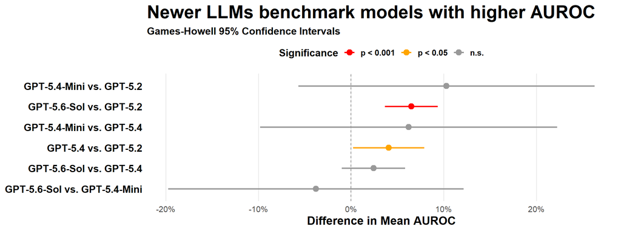

```r
display_labels <- c(
  "gpt-5.2"      = "GPT-5.2",
  "gpt-5.4"      = "GPT-5.4",
  "gpt-5.4-mini" = "GPT-5.4-Mini",
  "gpt-5.6-sol"  = "GPT-5.6-Sol"
)

post_hoc_plot_data <- post_hoc %>%
  mutate(
    Group1      = display_labels[as.character(group1)],
    Group2      = display_labels[as.character(group2)],
    Comparison  = paste(Group2, "vs.", Group1),
    Significant = case_when(
      p.adj < 0.001 ~ "p < 0.001",
      p.adj < 0.05  ~ "p < 0.05",
      TRUE          ~ "n.s."
    )
  ) %>%
  arrange(estimate)

post_hoc_plot_data$Comparison <- factor(post_hoc_plot_data$Comparison,
                                         levels = post_hoc_plot_data$Comparison)

post_hoc_plot_data$Significant <- factor(post_hoc_plot_data$Significant,
                                          levels = c("p < 0.001", "p < 0.05", "n.s."))

p <- ggplot(post_hoc_plot_data, aes(x = estimate, y = Comparison, color = Significant)) +
  geom_vline(xintercept = 0, linetype = "dashed", color = "gray50", linewidth = 0.5) +
  geom_errorbarh(aes(xmin = conf.low, xmax = conf.high), height = 0, linewidth = 0.9) +
  geom_point(size = 3.5) +
  scale_color_manual(
    values = c("p < 0.001" = "red", "p < 0.05" = "orange", "n.s." = "gray60"),
    name   = "Significance"
  ) +
  scale_x_continuous(labels = scales::percent_format(accuracy = 1)) +
  labs(
    title    = "Newer LLMs benchmark models with higher AUROC",
    subtitle = "Games-Howell 95% Confidence Intervals",
    x        = "Difference in Mean AUROC",
    y        = NULL
  ) +
  theme_minimal(base_size = 14) +
  theme(
    legend.position    = "top",
    plot.title         = element_text(color = "black", face = "bold", size = 25),
    plot.subtitle      = element_text(color = "black", face = "bold", size = 14),
    axis.title         = element_text(color = "black", face = "bold"),
    axis.text.y          = element_text(color = "black", face = "bold", size = 14),
    legend.title       = element_text(color = "black", face = "bold"),
    legend.text        = element_text(color = "black", face = "bold"),
    panel.grid.minor   = element_blank(),
    panel.grid.major.y = element_blank(),
    axis.title.x = element_text(color = "black", face = "bold", size = 16)
  )

p
```

```r
ggsave(
  filename = "auroc_pairwise_differences.png",
  plot     = p,
  width    = 12,
  height   = 6,
  dpi      = 600,       # good for print/slides; use 150 if it's just for a webpage
  bg       = "white"    # theme_minimal has a transparent background by default —
                         # without this, the PNG can look odd when dropped onto
                         # a non-white slide/background
)
```

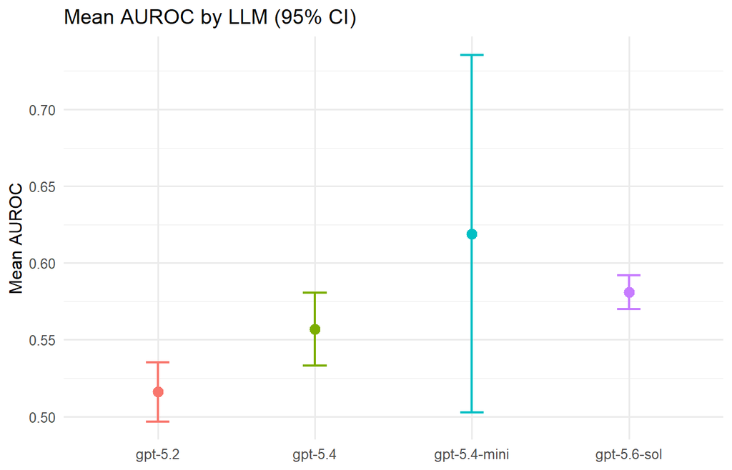

```r
group_ci <- df_run %>%
  group_by(group) %>%
  summarise(
    mean_auroc = mean(auroc, na.rm = TRUE),
    sd_auroc   = sd(auroc, na.rm = TRUE),
    n          = sum(!is.na(auroc)),
    se_auroc   = sd_auroc / sqrt(n),
    t_crit     = qt(0.975, df = n - 1),
    ci_low     = mean_auroc - t_crit * se_auroc,
    ci_high    = mean_auroc + t_crit * se_auroc,
    .groups    = "drop"
  )

ggplot(group_ci, aes(x = group, y = mean_auroc, color = group)) +
  geom_errorbar(aes(ymin = ci_low, ymax = ci_high), width = 0.15, linewidth = 0.8) +
  geom_point(size = 3) +
  labs(
    title = "Mean AUROC by LLM (95% CI)",
    x = NULL, y = "Mean AUROC"
  ) +
  theme_minimal(base_size = 12) +
  theme(legend.position = "none")
```

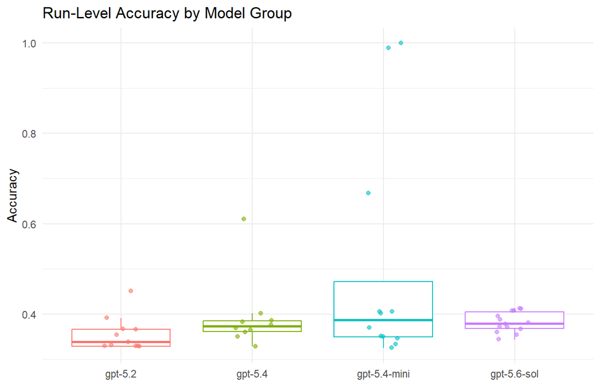

```r
ggplot(df_run, aes(x = group, y = accuracy, color = group)) +
  geom_boxplot(outlier.shape = NA) +
  geom_jitter(width = 0.15, alpha = 0.6) +
  labs(title = "Run-Level Accuracy by Model Group",
       x = NULL, y = "Accuracy") +
  theme_minimal() +
  theme(legend.position = "none")
```

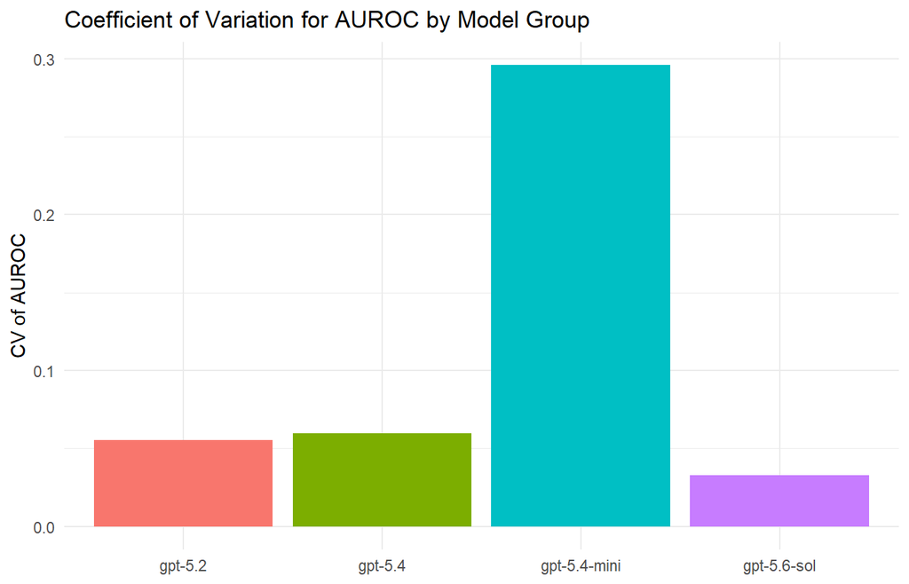

```r
ggplot(consistency_summary, aes(x = group, y = cv_auroc, fill = group)) +
  geom_col() +
  labs(title = "Coefficient of Variation for AUROC by Model Group",
       x = NULL, y = "CV of AUROC") +
  theme_minimal() +
  theme(legend.position = "none")
```

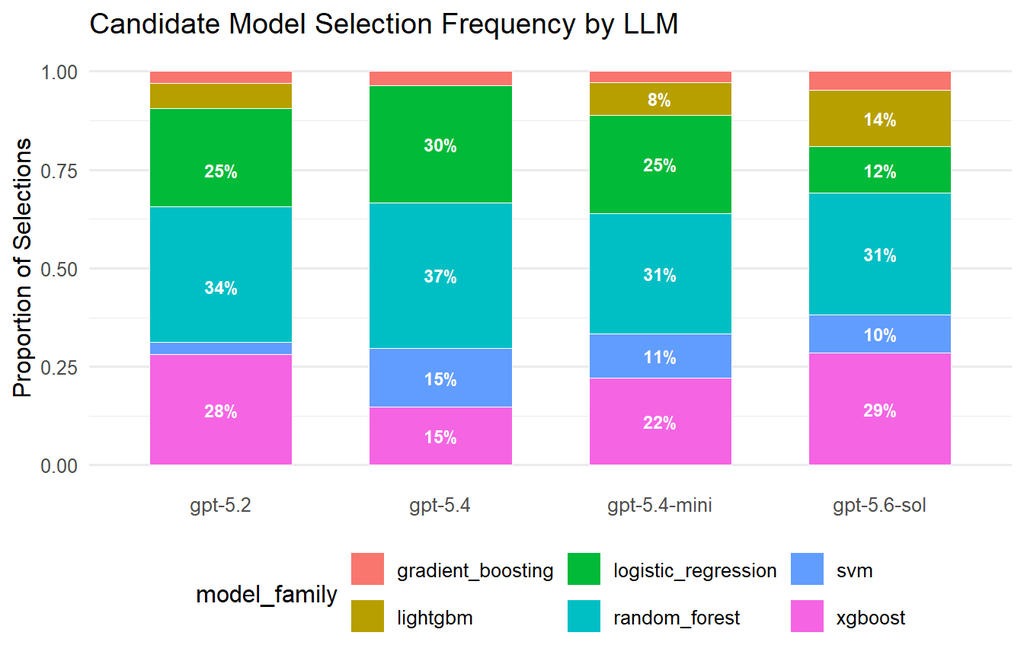

```r
library(scales)

ggplot(family_freq, aes(x = group, y = pct, fill = model_family)) +
  geom_col(width = 0.65, color = "white", linewidth = 0.3) +
  geom_text(
    data = subset(family_freq, pct >= 0.08),
    aes(label = percent(pct, accuracy = 1)),
    position = position_stack(vjust = 0.5),
    color = "white", size = 3.2, fontface = "bold",
    show.legend = FALSE
  ) +
  theme_minimal(base_size = 12) +
  theme(
    legend.position = "bottom",
    panel.grid.major.x = element_blank()
  ) +
  labs(
    title = "Candidate Model Selection Frequency by LLM",
    x = NULL, y = "Proportion of Selections"
  )
```

# 8 Conclusion

This experiment compared four LLMs (GPT-5.2, GPT-5.4, GPT-5.4-mini, and GPT-5.6-sol) used to configure candidate models for agentic AI benchmarking, holding all other pipeline parameters constant. From the statistical tests, we conclude that model means are **not** all equal for mean AUROC. GPT-5.4 and GPT-5.6-sol each achieve significantly higher mean AUROC than GPT-5.2, indicating a general trend of improved benchmarking capability in more advanced model versions.

Lastly, GPT-5.4-mini produced abnormally high variability across runs. This could be due to data leakage, but GPT-5.4-mini is worth further investigation.

## 8.1 Limitations

- **Missing XGBoost results.** Several runs have `NA` values for XGBoost because the package was unsuccessfuly implemented in the execution environment for those runs, not because the model underperformed. These `NA`s were excluded from run-level averages, but they are a pipeline/environment issue rather than a genuine model-comparison signal and should be corrected at the source in future runs.
- **Sample size.** Group sizes (10-14 runs) are modest for detecting small-to-moderate effect sizes. Larger sample sizes (> 30 runs) could result in more significant pairwise comparisons.